```python
from pathlib import Path
import numpy as np
import matplotlib.pyplot as plt
import pandas as pd
import matplotlib.pyplot as plt
from matplotlib.pyplot import figure
from sklearn import metrics
from sklearn.model_selection import train_test_split
from sklearn.metrics import confusion_matrix
from tensorflow.keras.models import Sequential
from tensorflow.keras.layers import LSTM, Dense, Dropout
from tensorflow.keras.optimizers import Adam
from tensorflow.keras.callbacks import EarlyStopping
from sklearn.metrics import accuracy_score, f1_score, confusion_matrix
from sklearn.model_selection import train_test_split
from tensorflow.keras.models import Sequential, Model
from tensorflow.keras.layers import LSTM, RepeatVector, TimeDistributed, Dense
from sklearn.metrics import classification_report
import seaborn as sns



def dataframe_from_csv(target):
    return pd.read_csv(target).rename(columns=lambda x: x.strip())

def dataframe_from_csvs(targets):
    return pd.concat([dataframe_from_csv(x) for x in targets])

TEST_DATASET = sorted([x for x in Path("./test1/").glob("*.csv")])
TRAIN_DATASET = sorted([x for x in Path("./train/").glob("*.csv")])
TEST_DF_RAW = dataframe_from_csvs(TEST_DATASET)
TRAIN_DF_RAW = dataframe_from_csvs(TRAIN_DATASET)
ATTACK_DF = TEST_DF_RAW['attack']
```

# 유효필드 정리

공정 변수와 관련 없는 값은 제거하였다. 그 이유는 전처리가 올바르게 되지 않을 수도 있기 때문이다.

```python
DROP_FIELD = ["time", "attack_P1", "attack_P2", "attack_P3","attack"]
VALID_COLUMNS_IN_TRAIN_DATASET = TRAIN_DF_RAW.columns.drop(DROP_FIELD) # DROP_FIELD를 통해 normalization에 사용하지 않을 변수를 제거함.
TAG_MIN = TRAIN_DF_RAW[VALID_COLUMNS_IN_TRAIN_DATASET].min()
TAG_MAX = TRAIN_DF_RAW[VALID_COLUMNS_IN_TRAIN_DATASET].max()
```

# 정규화

남은 공정 변수 중 가장 큰 값과 가장 작은 값을 구한 후 각 컬럼별로 Min-Max 정규화를 진행하였다.

```python
def normalize(df, TAG_MIN, TAG_MAX):
    ndf = df.copy()
    for c in df.columns:
        if TAG_MIN[c] == TAG_MAX[c]:
            ndf[c] = df[c] - TAG_MIN[c]
        else:
            ndf[c] = (df[c] - TAG_MIN[c]) / (TAG_MAX[c] - TAG_MIN[c])
    return ndf

# Min-Max Normalize
TRAIN_DF = normalize(TRAIN_DF_RAW[VALID_COLUMNS_IN_TRAIN_DATASET], TAG_MIN, TAG_MAX).ewm(alpha=0.9).mean()
TEST_DF = normalize(TEST_DF_RAW[VALID_COLUMNS_IN_TRAIN_DATASET], TAG_MIN, TAG_MAX).ewm(alpha=0.9).mean()
```

# 정규화 체크

정규화가 잘 진행 되었는 지 함수를 통해 체크하였다.

```python
def boundary_check(df):
    x = np.array(df, dtype=np.float32)
    return np.any(x > 1.0), np.any(x < 0), np.any(np.isnan(x))

# Boundary Check
print(boundary_check(TRAIN_DF))
```

```
(False, False, False)
```

# 슬라이딩 윈도우 적용

시계열 데이터를 더 잘 포착하게 하기 위해 슬라이딩 윈도우를 적용하였다.

[참고링크](https://developer-lionhong.tistory.com/35)

```python
#비지도 학습을 위한 데이터셋 구성
window_size = 60
label_size = 80000

def sliding_window_unsupervised(df_train, df_target, window_size, feature_columns, answer_column, rolling_size= 10):
    data = df_train[feature_columns].values
    data_test = df_target[feature_columns].values
    ma_values = df_target[feature_columns].rolling(rolling_size, min_periods=1).mean().values
    answers = answer_column.values

    num_samples = len(df_train)
    features = np.empty((num_samples, window_size, len(feature_columns)), dtype=np.float32)
    tests = np.empty((num_samples, window_size, len(feature_columns)), dtype=np.float32)
    train_targets = np.empty((num_samples, 1, len(feature_columns)), dtype=np.float32)
    targets = np.empty((num_samples, 1, len(feature_columns)), dtype=np.float32)
    answer_targets = np.empty(num_samples, dtype=int)
    ma_values = np.empty((num_samples, len(feature_columns)), dtype=np.float32)

    for i in range(num_samples - window_size):
        features[i] = data[i:i+window_size]
        tests[i] = data_test[i:i+window_size]
        train_targets[i] = data[i+window_size]
        targets[i] = data_test[i+window_size]
        answer_targets[i] = 1 if np.any(answers[i:i+window_size] == 1) else 0

    return features, targets, answer_targets, train_targets, tests, ma_values

features = []
targets = []
answers = []
trains = []
tests = []
ma = []
```

# 특정 컬럼 추출

"E-SFD: Explainable Sensor Fault Detection in the ICS Anomaly Detection System" 논문에 나온 내용을 바탕으로 P1 공정과 관련된 LSTM을 만들기 위해 P1 공정과 관련된 변수들만 추출하였다.

```python
feature_columns = ['P1_B2004', 'P1_B2016', 'P1_B3004', 'P1_B3005', 'P1_B4002', 'P1_B4005', 'P1_B400B',
                   'P1_B4022', 'P1_FCV01D', 'P1_FCV01Z', 'P1_FCV02D', 'P1_FCV02Z', 'P1_FCV03D',
                   'P1_FCV03Z', 'P1_FT01', 'P1_FT01Z', 'P1_FT02', 'P1_FT02Z', 'P1_FT03', 'P1_FT03Z',
                   'P1_LCV01D', 'P1_LIT01', 'P1_PCV01D', 'P1_PCV01Z', 'P1_PCV02D', 'P1_PCV02Z',
                   'P1_PIT01', 'P1_PIT02', 'P1_TIT01', 'P1_TIT02']

features, targets, answers, trains, tests, ma = sliding_window_unsupervised(TRAIN_DF[:label_size], TEST_DF[:label_size], 60, feature_columns, ATTACK_DF[:label_size], 10)
print(features.shape)
print(targets.shape)
print(answers.shape)
print(tests.shape)
print(trains.shape)
print(ma.shape)
```

```
(80000, 60, 30)
(80000, 1, 30)
(80000,)
(80000, 60, 30)
(80000, 1, 30)
(80000, 30)
```

# 모델 컴파일

마찬가지로 "E-SFD: Explainable Sensor Fault Detection in the ICS Anomaly Detection System" 논문에 나온 내용을 바탕으로 파라미터를 조정하였다.

```python
optimizer = Adam()

def build_autoencoder(window_size, num_features):
    model = Sequential()
    # 인코더
    model.add(LSTM(64, activation='relu', input_shape=(window_size, num_features), return_sequences=False))

    model.add(Dense(64))  # 잠재 공간 표현
    model.add(RepeatVector(1))  # 디코더로 전달할 시퀀스 재생성
    model.add(Dense(64))

    # 디코더
    model.add(LSTM(64, activation='relu', input_shape=(window_size+1, num_features), return_sequences=True))
    model.add(TimeDistributed(Dense(len(feature_columns))))

    model.compile(optimizer=optimizer, loss='mse')
    return model
```

```python
# 모델 생성
autoencoder = build_autoencoder(window_size, len(feature_columns))
autoencoder.summary()
```

[output not shown]

# Early Stopping

Early Stopping을 적용해서 모델 훈련 중 성과가 나아지지 않을 경우 일찍 종료되게 하였다.

```python
# EarlyStopping 설정
early_stopping = EarlyStopping(monitor='val_loss', patience=4, verbose=1)

# 모델 학습
history = autoencoder.fit(
    features,
    features,
    epochs=32,
    batch_size=512,
    verbose=1,
    callbacks=[early_stopping],  # 콜백 리스트에 추가
    validation_split=0.2  # 검증 데이터 분할 비율 설정
)
```

```
Epoch 19: early stopping
```

# 모델 예측

```python
# 모델로부터 예측값을 얻습니다.
predicted = autoencoder.predict(tests)
```

# 출력 shape 비교

출력 값이 잘 나왔나 확인하기 위해 shape를 출력하였다.

```python
print(predicted.shape)
print(targets.shape)
print(trains.shape)
```

```
(80000, 1, 30)
(80000, 1, 30)
(80000, 1, 30)
```

# 임계값 설정

예측값과 실제값의 차이를 바탕으로 특정 임계값이 넘어가면 이상으로 본다.

```python
def check_anomaly(predicted_table, target_table, threshold):
    predicted_table[target_table >= threshold] = 1
    return predicted_table
```

```python
def calculate_table(predicted, targets):
    differences = np.abs(predicted - targets)
    # 이동평균 값
    pt = np.mean(differences, axis=2).flatten()
    ma_values = np.mean(ma, axis=1)
    as_t = (ma_values + pt) / 2
    return as_t
```

```python
differences = np.abs(predicted - targets)
# 차이의 합을 각 샘플의 특성에 대해 계산
sum = differences.sum(axis=2)
averages = sum / len(feature_columns)
as_t = calculate_table(predicted, targets)
predicted_table = np.zeros(len(as_t))

predicted_table = check_anomaly(predicted_table, as_t.flatten(), 0.16)
print(as_t.shape)
```

```
(80000,)
```

# 시각화

그래프를 통해 임계값을 추리할 수 있기 때문에 데이터를 시각화 하였다.

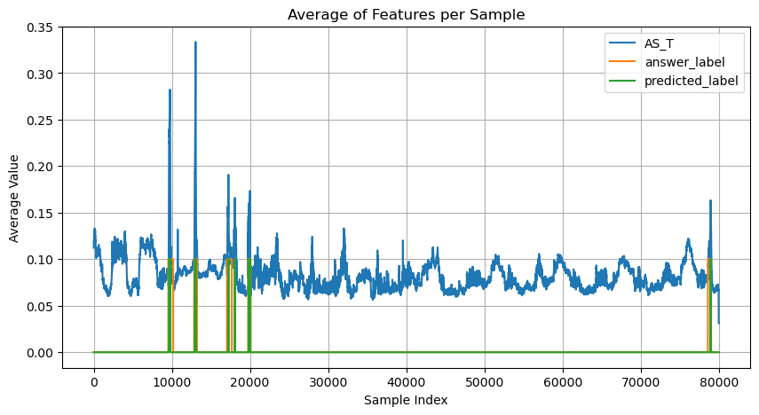

```python
# 시각화
plt.figure(figsize=(10, 5))
plt.plot(as_t, label = "AS_T")
plt.plot(answers * 0.1, label = "answer_label")
plt.plot(predicted_table * 0.1, label = "predicted_label")
plt.legend()
plt.title('Average of Features per Sample')
plt.xlabel('Sample Index')
plt.ylabel('Average Value')
plt.grid(True)
plt.show()
```

```python
print(predicted_table.shape, answers.shape)
```

```
(80000,) (80000,)
```

```python
# 실제 공격 레이블과의 비교
print("Classification Report:")
print(classification_report(predicted_table, answers[:len(predicted_table)]))

print("Accuracy Score:")
print(accuracy_score(predicted_table, answers[:len(predicted_table)]))
print()

print("F1 Score:")
print(f1_score(predicted_table, answers[:len(predicted_table)], average='weighted'))  # 'macro', 'micro', 'weighted' 등 필요에 따라 조정
print()

# Confusion Matrix 출력
cm = confusion_matrix(predicted_table, answers[:len(predicted_table)])
print("Confusion Matrix:")
print(cm)
```

```
Classification Report:
              precision    recall  f1-score   support

         0.0       1.00      0.98      0.99     79508
         1.0       0.21      0.99      0.34       492

    accuracy                           0.98     80000
   macro avg       0.60      0.98      0.67     80000
weighted avg       1.00      0.98      0.98     80000

Accuracy Score:
0.976775

F1 Score:
0.9842188051010545

Confusion Matrix:
[[77654  1854]
 [    4   488]]
```